# Latest-Available 2024 UC Salary Comparison: Observed Cohorts and Official Benchmarks

Robert J. Dellinger

March 31, 2026

This report is the repository’s main public-facing 2024 cross-sectional comparison. It combines focused person-level Transparent California cohorts that remain tractable to scrape with official UCOP salary-scale tables that provide the more defensible benchmark source for large academic and graduate-worker title series.

> Interpretive note: the current Transparent California University of California page is `2024`, but it remains labeled `Data Collection in Progress` (Transparent California 2026b). This report therefore treats `2024` as the latest available University of California year rather than a finalized census, and it keeps observed person-level compensation, UCOP benchmark ranges, and mixed-source comparison layers analytically distinct.

## Analytic overview

The objective is to produce publication-quality, advocacy-ready salary analysis for the University of California that combines the latest available 2024 observed compensation for tractable person-level cohorts from Transparent California with official 2024-25 UCOP pay-scale benchmarks for graduate-worker, postdoctoral, and ladder-rank professor title series.

### Source basis

The report uses the latest available 2024 person-level actual-pay cohorts scraped from Transparent California for police employees, librarians, chancellors, and the UC president (Transparent California 2026a, 2026b), and official 2024-25 UCOP salary-scale tables for graduate workers, postdoctoral scholars, and ladder-rank professor benchmarks (University of California Office of the President 2024b, 2024c, 2024d, 2024a).

### Source documentation and cohort design

Transparent California provides record-level pay components, which makes it useful for police and executive analysis, but the site still blocks deeper pagination on large academic and graduate-worker searches. Those larger cohorts are therefore represented here with official UCOP salary-scale tables rather than partial public-search results. In UCOP Table 18, `Group 1` covers campuses outside Berkeley, Los Angeles, and San Francisco, while `Group 2` covers Berkeley, Los Angeles, and San Francisco (University of California Office of the President 2024b). Table 22 and Table 23 are fiscal-year scales with explicit effective dates, while the professor benchmark remains an explicitly labeled ladder-rank academic salary-scale reference rather than realized pay (University of California Office of the President 2024c, 2024d, 2024a). This report collapses teaching assistant and teaching fellow rows into one broader `ASE instructional titles` benchmark for public-facing clarity while preserving the underlying `T018B` and `T018C` codes in the benchmark mapping table. Lecturer series are removed from the main comparison because the represented 2024 Unit 18 scales are analytically important but visually overwhelm the simpler cross-cohort comparison. The report continues to emphasize salary-plan codes such as `T001`, `T018B`, `T018C`, `T022`, and `T023` because those codes make the salary structures reusable for bargaining and organizing analysis (University of California Office of the President 2024b, 2024c, 2024d, 2024a).

### Comparison logic and estimands

The report uses median `total_pay_benefits` for observed Transparent California cohorts and annual salary-scale ranges for official UCOP benchmark cohorts. These are different source types and different estimands: observed medians summarize realized person-level annual compensation, while benchmark ranges summarize official salary structures rather than realized pay. The report also uses a Graduate Student Researcher floor benchmark:

- `ratio_to_gsr_floor = compensation_measure / 69,129`

where `69,129` is the 2024-25 annual `T022 Grade 1, Increment 1` GSR scale (University of California Office of the President 2024c).

## Setup and load packages

This section loads helper functions, packages, and file paths.

```r
knitr::opts_chunk$set(echo = TRUE, warning = FALSE, message = FALSE)

utility_path <- if (file.exists("scripts/functions/uc_salary_utils.R")) {
  "scripts/functions/uc_salary_utils.R"
} else {
  "functions/uc_salary_utils.R"
}

source(utility_path)
uc_salary_load_packages()

analysis_year <- 2024L
analytic_input <- uc_salary_path("data", "processed", paste0("uc_salary_", analysis_year, "_analytic_dataset.csv"))
benchmark_input <- uc_salary_path("data", "raw", "uc_reference", "uc_2024_25_pay_scale_benchmarks.csv")
actual_table_output <- uc_salary_path("outputs", "tables", paste0("uc_salary_", analysis_year, "_actual_median_compensation.csv"))
benchmark_table_output <- uc_salary_path("outputs", "tables", paste0("uc_salary_", analysis_year, "_benchmark_ranges.csv"))
benchmark_mapping_output <- uc_salary_path("outputs", "tables", paste0("uc_salary_", analysis_year, "_benchmark_mapping.csv"))
comparison_table_output <- uc_salary_path("outputs", "tables", paste0("uc_salary_", analysis_year, "_actual_vs_benchmark_comparison.csv"))
police_table_output <- uc_salary_path("outputs", "tables", paste0("uc_salary_", analysis_year, "_police_pay_components.csv"))
figure_manifest_output <- uc_salary_path("outputs", "logs", "qa", paste0("uc_salary_", analysis_year, "_figure_manifest.csv"))
report_qa_output <- uc_salary_path("outputs", "logs", "qa", paste0("uc_salary_", analysis_year, "_analysis_qa_summary.csv"))

instructional_ase_label <- "ASE instructional titles"
instructional_group_pattern <- "^(Teaching assistants|Teaching fellows)"
lecturer_benchmark_exclusions <- c(
  "Lecturers with potential SOE",
  "Lecturers with SOE",
  "Senior lecturers with SOE"
)
```

## Input validation for the mixed-source comparison

These checks matter because the report is only defensible if both the observed person-level cohort file and the benchmark file are present and populated before any aggregation begins.

```r
stopifnot(file.exists(analytic_input))
stopifnot(file.exists(benchmark_input))

analytic_data <- readr::read_csv(analytic_input, show_col_types = FALSE)
benchmark_data <- readr::read_csv(benchmark_input, show_col_types = FALSE)

stopifnot(nrow(analytic_data) > 0)
stopifnot(nrow(benchmark_data) > 0)

validation_summary <- tibble::tibble(
  validation_check = c(
    "Actual-pay rows available",
    "Benchmark rows available",
    "Actual-pay cohort groups available",
    "Benchmark cohort groups available"
  ),
  validation_result = c(
    nrow(analytic_data),
    nrow(benchmark_data),
    dplyr::n_distinct(analytic_data$cohort_group),
    dplyr::n_distinct(benchmark_data$cohort_group)
  )
)

knitr::kable(validation_summary)
```

| validation_check | validation_result |
| --- | --- |
| Actual-pay rows available | 970 |
| Benchmark rows available | 12 |
| Actual-pay cohort groups available | 3 |
| Benchmark cohort groups available | 3 |

## Observed cohorts and benchmark cohorts entering the comparison

This section imports the observed actual-pay and benchmark datasets used to build the final graphics and tables. The tables below are scope checks rather than final interpretive outputs: they show which observed cohorts and benchmark cohorts enter the cross-sectional comparison before any aggregation occurs.

### Scope tables before aggregation

The first table shows the tractable person-level cohorts from the focused Transparent California scrape. The second table shows the UCOP benchmark cohorts that will be collapsed or retained in the final public-facing comparison.

```r
analytic_data %>%
  dplyr::count(cohort_group, analysis_cohort, sort = TRUE) %>%
  knitr::kable()
```

| cohort_group | analysis_cohort | n |
| --- | --- | --- |
| Library workers | Librarians | 502 |
| Police | Police employees | 456 |
| Executive leadership | Chancellors | 11 |
| Executive leadership | UC president | 1 |

```r
benchmark_data %>%
  dplyr::filter(
    !analysis_cohort %in% lecturer_benchmark_exclusions
  ) %>%
  dplyr::mutate(
    grouped_analysis_cohort = dplyr::case_when(
      stringr::str_detect(analysis_cohort, instructional_group_pattern) ~ instructional_ase_label,
      TRUE ~ analysis_cohort
    )
  ) %>%
  dplyr::distinct(
    cohort_group,
    analysis_cohort = grouped_analysis_cohort,
    source_table,
    salary_plan_or_grade,
    range_label
  ) %>%
  knitr::kable()
```

| cohort_group | analysis_cohort | source_table | salary_plan_or_grade | range_label |
| --- | --- | --- | --- | --- |
| Graduate workers | Graduate student researchers | Table 22 | T022 Grade 1 | Increment 1 to 6 |
| Graduate workers | ASE instructional titles | Table 18 | T18B Grade 1 | Increment 1 to 3 |
| Graduate workers | ASE instructional titles | Table 18 | T18C Grade 1 | Increment 1 to 3 |
| Graduate workers | ASE instructional titles | Table 18 | T18B Grade 2 | Single annual rate |
| Graduate workers | ASE instructional titles | Table 18 | T18C Grade 2 | Single annual rate |
| Postdoctoral scholars | Postdoctoral scholars | Table 23 | T023 | Level 0 to 5 |
| Faculty and instruction | Assistant professors | Table 1 | T001 Grade 3 | Step 1 to 6 |
| Faculty and instruction | Associate professors | Table 1 | T001 Grade 2 | Step 1 to 5 |
| Faculty and instruction | Professors | Table 1 | T001 Grade 1 | Step 1 to 9 |

## Construction of comparison tables and publication figures

This section creates the summary tables and publication-quality graphics used in the report. Analytically, it moves through five steps: summarizing observed cohort medians, constructing grouped benchmark mappings, building the mixed-source comparison layer, isolating police cash-pay components, and saving the tables and figures that the report later renders inline.

```r
actual_medians <- analytic_data %>%
  dplyr::group_by(cohort_group, analysis_cohort) %>%
  dplyr::summarise(
    workers = dplyr::n(),
    median_regular_pay = stats::median(regular_pay, na.rm = TRUE),
    median_overtime_pay = stats::median(overtime_pay, na.rm = TRUE),
    median_other_pay = stats::median(other_pay, na.rm = TRUE),
    median_total_pay = stats::median(total_pay, na.rm = TRUE),
    median_total_pay_benefits = stats::median(total_pay_benefits, na.rm = TRUE),
    .groups = "drop"
  )

gsr_floor <- benchmark_data %>%
  dplyr::filter(analysis_cohort == "Graduate student researchers") %>%
  dplyr::pull(benchmark_low_annual)

benchmark_mapping <- benchmark_data %>%
  dplyr::mutate(
    grouped_analysis_cohort = dplyr::case_when(
      stringr::str_detect(analysis_cohort, instructional_group_pattern) ~ instructional_ase_label,
      TRUE ~ analysis_cohort
    ),
    included_in_main_comparison = !analysis_cohort %in% lecturer_benchmark_exclusions,
    source_type = "UCOP benchmark salary scale",
    inclusion_note = dplyr::case_when(
      grouped_analysis_cohort == instructional_ase_label ~ "Included in the main comparison as a broader ASE instructional benchmark; the underlying Table 18 TA and TF Group 1 and Group 2 codes remain preserved in this mapping table.",
      included_in_main_comparison ~ "Included in the main 2024 cross-sectional comparison.",
      TRUE ~ "Excluded from the main cross-sectional figure because Unit 18 lecturer scales are analytically distinct and visually overwhelm the core ladder-rank comparison."
    )
  )

benchmark_ranges <- benchmark_data %>%
  dplyr::filter(
    !analysis_cohort %in% lecturer_benchmark_exclusions
  ) %>%
  dplyr::mutate(
    grouped_analysis_cohort = dplyr::case_when(
      stringr::str_detect(analysis_cohort, instructional_group_pattern) ~ instructional_ase_label,
      TRUE ~ analysis_cohort
    ),
    grouped_range_label = dplyr::case_when(
      grouped_analysis_cohort == instructional_ase_label ~ "Table 18 Groups 1 and 2 combined across teaching assistant and teaching fellow titles",
      TRUE ~ range_label
    )
  ) %>%
  dplyr::group_by(cohort_group, analysis_cohort = grouped_analysis_cohort) %>%
  dplyr::summarise(
    source_table = paste(sort(unique(source_table)), collapse = " + "),
    salary_plan_or_grade = paste(sort(unique(salary_plan_or_grade)), collapse = " + "),
    range_label = dplyr::first(grouped_range_label),
    benchmark_low_annual = min(benchmark_low_annual, na.rm = TRUE),
    benchmark_high_annual = max(benchmark_high_annual, na.rm = TRUE),
    benchmark_low_monthly = min(benchmark_low_monthly, na.rm = TRUE),
    benchmark_high_monthly = max(benchmark_high_monthly, na.rm = TRUE),
    .groups = "drop"
  ) %>%
  dplyr::mutate(
    cohort_group = dplyr::recode(cohort_group, "Faculty and instruction" = "Ladder-rank professor benchmarks"),
    ratio_low_to_gsr_floor = benchmark_low_annual / gsr_floor,
    ratio_high_to_gsr_floor = benchmark_high_annual / gsr_floor
  )

actual_vs_benchmark <- dplyr::bind_rows(
  actual_medians %>%
    dplyr::transmute(
      cohort_group,
      analysis_cohort,
      measure_type = "Observed median total pay and benefits",
      value_low = median_total_pay_benefits,
      value_high = median_total_pay_benefits,
      display_value = median_total_pay_benefits,
      ratio_low_to_gsr_floor = median_total_pay_benefits / gsr_floor,
      ratio_high_to_gsr_floor = median_total_pay_benefits / gsr_floor,
      detail = paste0("n = ", workers)
    ),
  benchmark_ranges %>%
    dplyr::transmute(
      cohort_group,
      analysis_cohort,
      measure_type = "Official salary scale range",
      value_low = benchmark_low_annual,
      value_high = benchmark_high_annual,
      display_value = (benchmark_low_annual + benchmark_high_annual) / 2,
      ratio_low_to_gsr_floor,
      ratio_high_to_gsr_floor,
      detail = paste(source_table, salary_plan_or_grade, range_label, sep = " | ")
    )
) %>%
  dplyr::mutate(
    analysis_cohort = factor(
      analysis_cohort,
      levels = c(
        instructional_ase_label,
        "Graduate student researchers",
        "Postdoctoral scholars",
        "Assistant professors",
        "Associate professors",
        "Professors",
        "Librarians",
        "Police employees",
        "Chancellors",
        "UC president"
      )
    )
  )

police_pay_components <- analytic_data %>%
  dplyr::filter(cohort_group == "Police") %>%
  dplyr::group_by(police_role_group) %>%
  dplyr::summarise(
    workers = dplyr::n(),
    median_regular_pay = stats::median(regular_pay, na.rm = TRUE),
    median_overtime_pay = stats::median(overtime_pay, na.rm = TRUE),
    median_other_pay = stats::median(other_pay, na.rm = TRUE),
    median_total_pay = stats::median(total_pay, na.rm = TRUE),
    median_total_pay_benefits = stats::median(total_pay_benefits, na.rm = TRUE),
    .groups = "drop"
  ) %>%
  tidyr::pivot_longer(
    cols = c(median_regular_pay, median_overtime_pay, median_other_pay),
    names_to = "pay_component",
    values_to = "median_amount"
  ) %>%
  dplyr::mutate(
    pay_component = factor(
      pay_component,
      levels = c("median_regular_pay", "median_overtime_pay", "median_other_pay"),
      labels = c("Regular pay", "Overtime pay", "Other pay")
    )
  )

readr::write_csv(actual_medians, actual_table_output)
readr::write_csv(benchmark_ranges, benchmark_table_output)
readr::write_csv(benchmark_mapping, benchmark_mapping_output)
readr::write_csv(actual_vs_benchmark, comparison_table_output)
readr::write_csv(police_pay_components, police_table_output)

plot_actual_medians <- actual_medians %>%
  dplyr::mutate(
    analysis_cohort = factor(
      analysis_cohort,
      levels = actual_medians %>% dplyr::arrange(median_total_pay_benefits) %>% dplyr::pull(analysis_cohort)
    )
  ) %>%
  ggplot2::ggplot(ggplot2::aes(x = median_total_pay_benefits, y = analysis_cohort, fill = cohort_group)) +
  ggplot2::geom_col(width = 0.72) +
  ggplot2::geom_text(
    ggplot2::aes(label = scales::label_dollar(scale_cut = scales::cut_short_scale())(median_total_pay_benefits)),
    hjust = -0.08,
    size = 3.4,
    colour = "#1F2933"
  ) +
  ggplot2::scale_fill_manual(values = uc_salary_palette) +
  ggplot2::scale_x_continuous(labels = scales::label_dollar(scale_cut = scales::cut_short_scale()), expand = ggplot2::expansion(mult = c(0, 0.22))) +
  ggplot2::labs(
    title = uc_salary_wrap_text("Observed 2024 UC compensation medians for focused Transparent California cohorts", 62),
    subtitle = uc_salary_wrap_text("Person-level annual median total pay and benefits for the tractable cohorts captured in the focused 2024 scrape. The latest available 2024 UC page remains in progress.", 105),
    x = "Median total pay and benefits",
    y = NULL,
    fill = NULL,
    caption = uc_salary_wrap_text("Source type: person-level Transparent California realized compensation in nominal 2024 dollars. Benefits are employer-paid benefit costs, not take-home pay.", 135)
  ) +
  uc_salary_theme()
```

```r
plot_benchmark_ranges <- benchmark_ranges %>%
  dplyr::mutate(
    analysis_cohort = factor(
      analysis_cohort,
      levels = benchmark_ranges %>% dplyr::arrange(benchmark_high_annual) %>% dplyr::pull(analysis_cohort)
    )
  ) %>%
  ggplot2::ggplot(ggplot2::aes(y = analysis_cohort, x = benchmark_low_annual, xend = benchmark_high_annual, colour = cohort_group)) +
  ggplot2::geom_segment(linewidth = 5, lineend = "round") +
  ggplot2::geom_point(ggplot2::aes(x = benchmark_low_annual), size = 2.6, colour = "#1F2933") +
  ggplot2::geom_point(ggplot2::aes(x = benchmark_high_annual), size = 2.6, colour = "#1F2933") +
  ggplot2::scale_colour_manual(values = uc_salary_palette[names(uc_salary_palette) %in% unique(benchmark_ranges$cohort_group)]) +
  ggplot2::scale_x_continuous(labels = scales::label_dollar(scale_cut = scales::cut_short_scale()), expand = ggplot2::expansion(mult = c(0.02, 0.08))) +
  ggplot2::labs(
    title = uc_salary_wrap_text("Official 2024-25 UC salary-scale ranges for selected benchmark cohorts", 62),
    subtitle = uc_salary_wrap_text("UCOP benchmark ranges for ASE instructional titles, graduate student researchers, postdoctoral scholars, and ladder-rank professor series.", 105),
    x = "Annual salary scale amount",
    y = NULL,
    colour = NULL,
    caption = uc_salary_wrap_text("Source type: UCOP salary scales. These are official benchmark ranges, not observed realized pay. Tables shown here: T018B/T018C, T022, T023, and T001.", 135)
  ) +
  uc_salary_theme()

plot_actual_vs_benchmark <- ggplot2::ggplot(actual_vs_benchmark) +
  ggplot2::geom_segment(
    data = dplyr::filter(actual_vs_benchmark, measure_type == "Official salary scale range"),
    ggplot2::aes(y = analysis_cohort, yend = analysis_cohort, x = value_low, xend = value_high, colour = cohort_group),
    linewidth = 5,
    lineend = "round",
    alpha = 0.8
  ) +
  ggplot2::geom_point(
    data = dplyr::filter(actual_vs_benchmark, measure_type == "Observed median total pay and benefits"),
    ggplot2::aes(y = analysis_cohort, x = display_value, fill = cohort_group),
    shape = 21,
    size = 4.2,
    colour = "#1F2933",
    stroke = 0.7
  ) +
  ggplot2::scale_colour_manual(values = uc_salary_palette) +
  ggplot2::scale_fill_manual(values = uc_salary_palette) +
  ggplot2::scale_x_continuous(labels = scales::label_dollar(scale_cut = scales::cut_short_scale()), expand = ggplot2::expansion(mult = c(0.02, 0.10))) +
  ggplot2::guides(
    colour = ggplot2::guide_legend(nrow = 2, byrow = TRUE),
    fill = ggplot2::guide_legend(nrow = 2, byrow = TRUE)
  ) +
  ggplot2::labs(
    title = uc_salary_wrap_text("Observed 2024 compensation and official 2024-25 benchmark ranges", 62),
    subtitle = uc_salary_wrap_text("Points are observed person-level median total pay and benefits; segments are official UCOP salary-scale ranges. The ASE benchmark combines Table 18 teaching assistant and teaching fellow titles.", 105),
    x = "Annual amount",
    y = NULL,
    fill = NULL,
    colour = NULL,
    caption = uc_salary_wrap_text("Mixed-source comparison: person-level Transparent California realized compensation in nominal 2024 dollars versus UCOP benchmark salary scales. Source types are not interchangeable.", 135)
  ) +
  uc_salary_theme()

plot_ratio_to_gsr_floor <- ggplot2::ggplot(actual_vs_benchmark) +
  ggplot2::geom_segment(
    data = dplyr::filter(actual_vs_benchmark, measure_type == "Official salary scale range"),
    ggplot2::aes(y = analysis_cohort, yend = analysis_cohort, x = ratio_low_to_gsr_floor, xend = ratio_high_to_gsr_floor, colour = cohort_group),
    linewidth = 5,
    lineend = "round",
    alpha = 0.8
  ) +
  ggplot2::geom_point(
    data = dplyr::filter(actual_vs_benchmark, measure_type == "Observed median total pay and benefits"),
    ggplot2::aes(y = analysis_cohort, x = ratio_high_to_gsr_floor, fill = cohort_group),
    shape = 21,
    size = 4.2,
    colour = "#1F2933",
    stroke = 0.7
  ) +
  ggplot2::geom_vline(xintercept = 1, linewidth = 0.8, linetype = "dashed", colour = "#7B8794") +
  ggplot2::scale_colour_manual(values = uc_salary_palette) +
  ggplot2::scale_fill_manual(values = uc_salary_palette) +
  ggplot2::scale_x_continuous(expand = ggplot2::expansion(mult = c(0.02, 0.10))) +
  ggplot2::guides(
    colour = ggplot2::guide_legend(nrow = 2, byrow = TRUE),
    fill = ggplot2::guide_legend(nrow = 2, byrow = TRUE)
  ) +
  ggplot2::labs(
    title = uc_salary_wrap_text("Observed 2024 compensation and benchmark ranges relative to the GSR floor", 62),
    subtitle = uc_salary_wrap_text("The reference value 1.0 equals the 2024-25 Table 22 Graduate Student Researcher floor of $69,129.", 105),
    x = "Ratio to the GSR annual salary floor",
    y = NULL,
    fill = NULL,
    colour = NULL,
    caption = uc_salary_wrap_text("Mixed-source ratio comparison. Points use observed person-level Transparent California medians in nominal 2024 dollars; segments use UCOP benchmark ranges.", 135)
  ) +
  uc_salary_theme()

plot_police_pay_components <- ggplot2::ggplot(police_pay_components, ggplot2::aes(x = median_amount, y = police_role_group, fill = pay_component)) +
  ggplot2::geom_col(width = 0.72) +
  ggplot2::scale_fill_manual(values = c("Regular pay" = "#3E7CB1", "Overtime pay" = "#D1495B", "Other pay" = "#EDA247")) +
  ggplot2::scale_x_continuous(labels = scales::label_dollar(scale_cut = scales::cut_short_scale()), expand = ggplot2::expansion(mult = c(0, 0.05))) +
  ggplot2::labs(
    title = uc_salary_wrap_text("Observed 2024 police cash-pay components by police role group", 62),
    subtitle = uc_salary_wrap_text("Person-level median regular pay, overtime pay, and other pay for police leadership/supervision versus police officers and other police titles.", 105),
    x = "Median pay component amount",
    y = NULL,
    fill = NULL,
    caption = uc_salary_wrap_text("Source type: person-level Transparent California realized pay components in nominal 2024 dollars. Benefits are omitted so the cash-pay composition is easier to compare.", 135)
  ) +
  uc_salary_theme()
```

```r
figure_manifest <- tibble::tibble(
  figure = c(
    "Actual median compensation for accessible cohorts",
    "Official benchmark salary-scale ranges",
    "Actual medians overlaid on benchmark ranges",
    "Ratios to the GSR salary floor",
    "Police pay components"
  ),
  output_path = c(
    uc_salary_save_plot(plot_actual_medians, "uc_salary_2024_actual_medians.png", width = 12, height = 7.5),
    uc_salary_save_plot(plot_benchmark_ranges, "uc_salary_2024_benchmark_ranges.png", width = 13, height = 8.5),
    uc_salary_save_plot(plot_actual_vs_benchmark, "uc_salary_2024_actual_vs_benchmark.png", width = 13, height = 8.5),
    uc_salary_save_plot(plot_ratio_to_gsr_floor, "uc_salary_2024_ratio_to_gsr_floor.png", width = 13, height = 8.5),
    uc_salary_save_plot(plot_police_pay_components, "uc_salary_2024_police_pay_components.png", width = 12, height = 7.5)
  )
)

readr::write_csv(figure_manifest, figure_manifest_output)
```

## Final comparison tables and figures

This section reviews the finished summary tables that support the report narrative and then renders the saved figures inline so the HTML report itself functions as the main interpretive product rather than only a manifest of exported PNG files.

### Summary result tables

These tables show the two main source families that underpin the report: observed person-level medians and official benchmark ranges.

```r
actual_medians %>%
  dplyr::arrange(dplyr::desc(median_total_pay_benefits)) %>%
  dplyr::select(analysis_cohort, workers, median_total_pay, median_total_pay_benefits) %>%
  knitr::kable()
```

| analysis_cohort | workers | median_total_pay | median_total_pay_benefits |
| --- | --- | --- | --- |
| UC president | 1 | 1178977.0 | 1250206.0 |
| Chancellors | 11 | 693644.0 | 765687.0 |
| Police employees | 456 | 175009.5 | 192366.0 |
| Librarians | 502 | 113909.0 | 143157.5 |

```r
benchmark_ranges %>%
  dplyr::select(analysis_cohort, salary_plan_or_grade, benchmark_low_annual, benchmark_high_annual) %>%
  dplyr::arrange(benchmark_low_annual) %>%
  knitr::kable()
```

| analysis_cohort | salary_plan_or_grade | benchmark_low_annual | benchmark_high_annual |
| --- | --- | --- | --- |
| Postdoctoral scholars | T023 | 66737 | 80034 |
| ASE instructional titles | T18B Grade 1 + T18B Grade 2 + T18C Grade 1 + T18C Grade 2 | 68000 | 86644 |
| Graduate student researchers | T022 Grade 1 | 69129 | 100406 |
| Assistant professors | T001 Grade 3 | 78200 | 101400 |
| Associate professors | T001 Grade 2 | 96500 | 121600 |
| Professors | T001 Grade 1 | 112900 | 205400 |

### Rendered figures by estimand

The following subsections render the same figures that are written to `outputs/figures/`, so readers can review descriptive, structural, and mixed-source visuals in context.

#### Observed realized-compensation medians

This figure is the repository’s observed-compensation entry point. It should be read strictly as a focused person-level cohort comparison from the latest available 2024 Transparent California UC page.

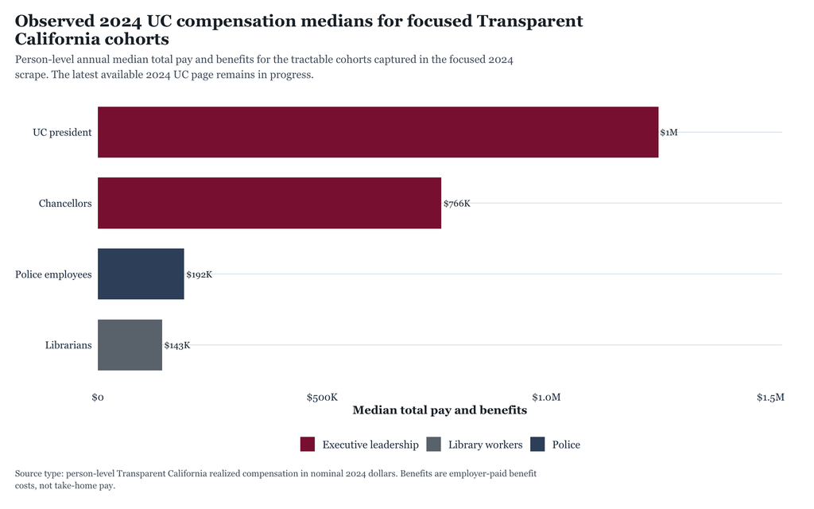

```r
plot_actual_medians
```

#### Official benchmark salary scales

This figure is the structural reference panel for bargaining and pay-scale interpretation. It summarizes official UCOP salary schedules rather than realized pay.

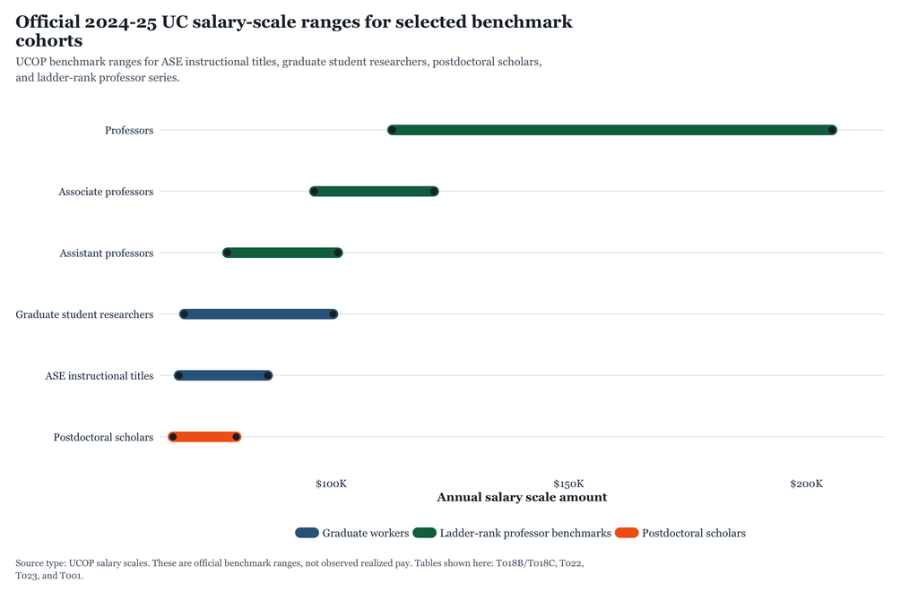

```r
plot_benchmark_ranges
```

#### Mixed-source overlay of observed medians and benchmark ranges

This mixed-source figure is the core comparison output. It is only defensible because the point and segment layers remain explicitly labeled as different source types and different estimands.

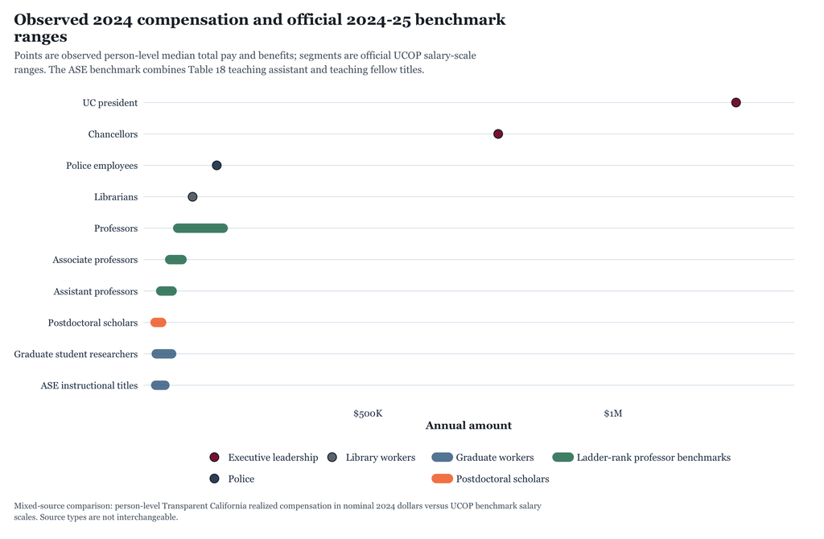

```r
plot_actual_vs_benchmark
```

#### Mixed-source ratios to the GSR floor

This figure turns the same comparison into a scale-relative view anchored to the official Graduate Student Researcher floor under Table 22.

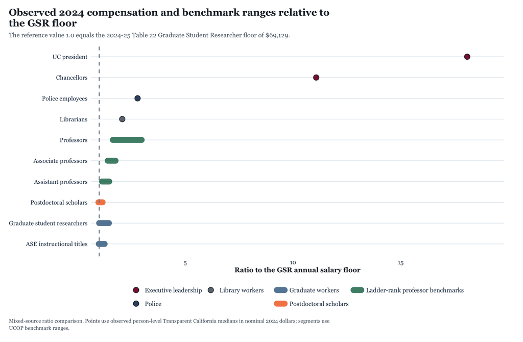

```r
plot_ratio_to_gsr_floor
```

#### Police cash-pay composition

This figure stays within the person-level Transparent California police cohort and breaks out the main cash-pay components before employer-paid benefits are added back in.

[figure not shown]

```r
plot_police_pay_components
```

## Report-level validation checks

This section verifies that the report-level tables and figures were written successfully and that the mixed-source comparison still rests on the expected observed cohorts, benchmark cohorts, and GSR reference value.

```r
report_qa_summary <- tibble::tibble(
  qa_metric = c(
    "Figures written",
    "Actual-pay cohorts summarized",
    "Benchmark cohorts summarized",
    "Police rows available",
    "Executive leadership rows available",
    "GSR benchmark floor used in ratio analysis"
  ),
  qa_value = c(
    nrow(figure_manifest),
    nrow(actual_medians),
    nrow(benchmark_ranges),
    sum(analytic_data$cohort_group == "Police"),
    sum(analytic_data$cohort_group == "Executive leadership"),
    gsr_floor
  )
)

readr::write_csv(report_qa_summary, report_qa_output)

report_qa_summary %>%
  knitr::kable()
```

| qa_metric | qa_value |
| --- | --- |
| Figures written | 5 |
| Actual-pay cohorts summarized | 4 |
| Benchmark cohorts summarized | 6 |
| Police rows available | 456 |
| Executive leadership rows available | 12 |
| GSR benchmark floor used in ratio analysis | 69129 |

## Saved tables, figures, and report artifacts

This artifact registry functions as a reproducibility appendix rather than a findings table. The labels below distinguish observed-compensation outputs from benchmark outputs and from mixed-source comparison outputs.

```r
export_manifest <- dplyr::bind_rows(
  tibble::tibble(
    artifact = c(
      "Observed 2024 actual-pay median table",
      "Official 2024-25 benchmark range table",
      "Official benchmark mapping table",
      "Observed-versus-benchmark comparison table",
      "Observed 2024 police pay-component table",
      "Cross-sectional figure manifest",
      "Cross-sectional report QA summary"
    ),
    output_path = c(
      actual_table_output,
      benchmark_table_output,
      benchmark_mapping_output,
      comparison_table_output,
      police_table_output,
      figure_manifest_output,
      report_qa_output
    )
  ),
  figure_manifest %>%
    dplyr::rename(artifact = figure)
)

export_manifest %>%
  dplyr::mutate(output_path = uc_salary_relpath(output_path)) %>%
  knitr::kable()
```

| artifact | output_path |
| --- | --- |
| Observed 2024 actual-pay median table | outputs/tables/uc_salary_2024_actual_median_compensation.csv |
| Official 2024-25 benchmark range table | outputs/tables/uc_salary_2024_benchmark_ranges.csv |
| Official benchmark mapping table | outputs/tables/uc_salary_2024_benchmark_mapping.csv |
| Observed-versus-benchmark comparison table | outputs/tables/uc_salary_2024_actual_vs_benchmark_comparison.csv |
| Observed 2024 police pay-component table | outputs/tables/uc_salary_2024_police_pay_components.csv |
| Cross-sectional figure manifest | outputs/logs/qa/uc_salary_2024_figure_manifest.csv |
| Cross-sectional report QA summary | outputs/logs/qa/uc_salary_2024_analysis_qa_summary.csv |
| Actual median compensation for accessible cohorts | outputs/figures/uc_salary_2024_actual_medians.png |
| Official benchmark salary-scale ranges | outputs/figures/uc_salary_2024_benchmark_ranges.png |
| Actual medians overlaid on benchmark ranges | outputs/figures/uc_salary_2024_actual_vs_benchmark.png |
| Ratios to the GSR salary floor | outputs/figures/uc_salary_2024_ratio_to_gsr_floor.png |
| Police pay components | outputs/figures/uc_salary_2024_police_pay_components.png |

## Closing interpretation

This report combines latest-available `2024` observed person-level compensation for focused, tractable University of California cohorts with official `2024-25` UC salary scales for larger academic title series. Those measures answer related but different questions, so the strongest headline contrasts in this report should be read as a mixed-source comparison between realized compensation and benchmark salary structures rather than as direct like-for-like pay equivalence.

# Works Cited

This section is reserved for the bibliography generated from the report citations.

Transparent California. 2026a. *2011–2024 Salaries for University of California*. https://transparentcalifornia.com/salaries/university-of-california/.

Transparent California. 2026b. *2024 Salaries for University of California*. https://transparentcalifornia.com/salaries/2024/university-of-california/.

University of California Office of the President. 2024a. *2024-25 Academic Salary Scales, Table 1: Faculty - Ladder Ranks - Professor Series*. https://www.ucop.edu/academic-personnel-programs/_files/2024-25/oct-2024-scales/t1.pdf.

University of California Office of the President. 2024b. *2024-25 Academic Salary Scales, Table 18: Student Titles*. https://www.ucop.edu/academic-personnel-programs/_files/2024-25/oct-2024-scales/t18.pdf.

University of California Office of the President. 2024c. *2024-25 Academic Salary Scales, Table 22: Graduate Student Researcher Titles*. https://www.ucop.edu/academic-personnel-programs/_files/2024-25/oct-2024-scales/t22.pdf.

University of California Office of the President. 2024d. *2024-25 Academic Salary Scales, Table 23: Postdoctoral Scholar Salary Scales*. https://www.ucop.edu/academic-personnel-programs/_files/2024-25/oct-2024-scales/t23.pdf.